# Activity Monitoring - Reproducible research project

Michalis Frangos

## Data description

This assignment makes use of data from a personal activity monitoring device. This device collects data at 5 minute intervals through out the day. The data consists of two months of data from an anonymous individual collected during the months of October and November, 2012 and include the number of steps taken in 5 minute intervals each day.

The variables included in this dataset are: * steps: Number of steps taking in a 5-minute interval (missing values as 𝙽𝙰) * date: The date on which the measurement was taken in YYYY-MM-DD format * interval: Identifier for the 5-minute interval in which measurement was taken

The dataset is stored in a comma-separated-value (CSV) file and there are a total of 17,568 observations in this dataset.

Data can be found [here][1] [1]: https://d396qusza40orc.cloudfront.net/repdata%2Fdata%2Factivity.zip “here”

## Downloading and unzipping dataset

```r
fileName <- "activity.csv"
fileUrl <- "https://d396qusza40orc.cloudfront.net/repdata%2Fdata%2Factivity.zip"

if (!file.exists("downloads") & !file.exists(fileName)){
        message("- downloading data")
        dir.create("downloads")
        download.file(fileUrl,destfile = "./downloads/project_data.zip",method = "auto")
        dateDownloaded <- date()
        message("- data downloaded")
} else {
        message("- data already downloaded")
}
```

```
## - data already downloaded
```

```r
if  (!file.exists(fileName)){
        message("- unzipping data")
        unzip("./downloads/project_data.zip")
        message("- data unzipped")
} else {
        message("- data file exists")
}
```

```
## - data file exists
```

## Reading in and processing data

```r
# read csv file
data <- read.csv(fileName,na.strings = "NA")
# Convert the Date variable to date class in R
data$date <- as.Date(data$date,"%Y-%m-%d") # %>% as.Date("%d/%m/%Y")
# look at data
head(data)
```

```
##   steps       date interval
## 1    NA 2012-10-01        0
## 2    NA 2012-10-01        5
## 3    NA 2012-10-01       10
## 4    NA 2012-10-01       15
## 5    NA 2012-10-01       20
## 6    NA 2012-10-01       25
```

# What is mean total number of steps taken per day?

```r
library(dplyr)

# Convert the Date variable to date class in R
dataMutated <- group_by(data,date) %>%
        summarize(stepsPerDay = sum(steps,na.rm= TRUE))
head(dataMutated)
```

```
## Source: local data frame [6 x 2]
##
##         date stepsPerDay
##       (date)       (int)
## 1 2012-10-01           0
## 2 2012-10-02         126
## 3 2012-10-03       11352
## 4 2012-10-04       12116
## 5 2012-10-05       13294
## 6 2012-10-06       15420
```

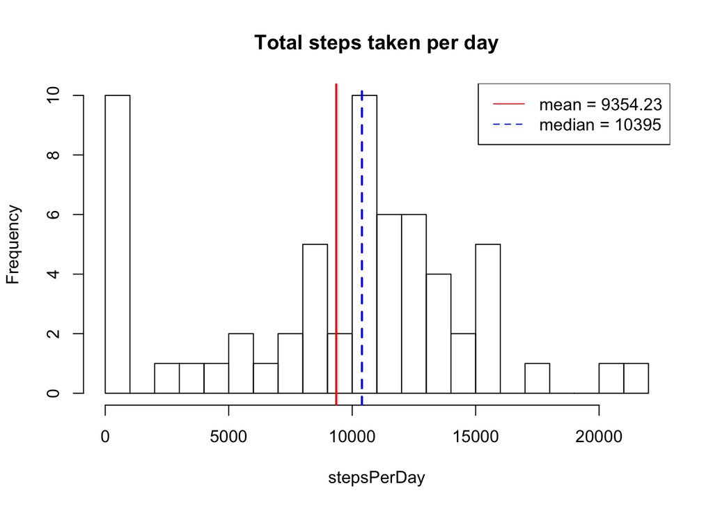

```r
mean_stepsPerDay = mean(dataMutated$stepsPerDay, na.rm = TRUE)
median_stepsPerDay = median(dataMutated$stepsPerDay, na.rm = TRUE)

text_legend1 <- paste("mean",round(mean_stepsPerDay,digits=2),sep = " = ")
text_legend2 <- paste("median",round(median_stepsPerDay,digits=2),sep = " = ")
with(dataMutated,{ hist(stepsPerDay,
                        main = "Total steps taken per day",breaks = 30)
        abline(v = mean_stepsPerDay,col = "red",lwd = 2)
        abline(v = median_stepsPerDay,col = "blue",lwd = 2,lty=2)
        legend("topright",lty=c(1,2),col=c("red","blue"),
               legend=c(text_legend1,text_legend2) ) })
```

# What is the average daily activity pattern?

```r
library(ggplot2)
dataMutated <- group_by(data,interval) %>%
        summarize(meanSteps = mean(steps,na.rm= TRUE))
head(dataMutated)
```

```
## Source: local data frame [6 x 2]
##
##   interval meanSteps
##      (int)     (dbl)
## 1        0 1.7169811
## 2        5 0.3396226
## 3       10 0.1320755
## 4       15 0.1509434
## 5       20 0.0754717
## 6       25 2.0943396
```

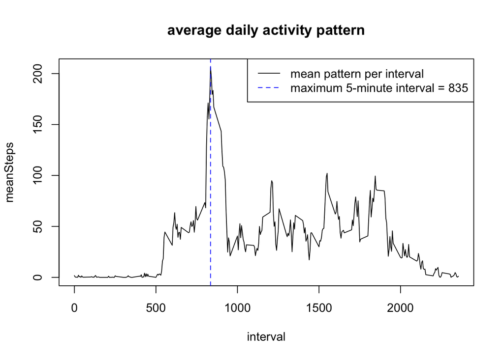

```r
max_index <- which.max(dataMutated$meanSteps)
max_interval <- dataMutated$interval[max_index]
max_steps <- dataMutated$meanSteps[max_index]

text_legend1 <-"mean pattern per interval"
text_legend2 <- paste("maximum 5-minute interval",max_interval,sep = " = ")
with(dataMutated,{ plot(interval,meanSteps,
                        main = "average daily activity pattern",type = "l")
        abline(v = max_interval,col = "blue",lwd = 1,lty = 2)
        legend("topright",lty=c(1,2),col=c("black","blue"),
               legend=c(text_legend1,text_legend2))
})
```

# Imputing missing values

- The number of missing values in data is:

```r
ok <- complete.cases(data)
print(sum(!ok))
```

```
## [1] 2304
```

- Filling missing values in the dataset by replacing with mean of interval

```r
library(ggplot2)

df <- group_by(data,interval) %>%
        summarize(meanSteps = mean(steps,na.rm= TRUE))
df <- merge(df,data)
ok <- complete.cases(df)             # find which entries to replace
df$steps[!ok] <- df$meanSteps[!ok]   # replace with mean of interval
df <- subset(df, select = names(data))%>%
        arrange(desc(date))         # order by date as in original data

head(df)
```

```
##       steps       date interval
## 1 1.7169811 2012-11-30        0
## 2 0.3396226 2012-11-30        5
## 3 0.1320755 2012-11-30       10
## 4 0.1509434 2012-11-30       15
## 5 0.0754717 2012-11-30       20
## 6 2.0943396 2012-11-30       25
```

- What is mean total number of steps taken per day?

```r
dataMutated <- group_by(df,date) %>%
        summarize(stepsPerDay = sum(steps,na.rm= TRUE))
mean_stepsPerDay = mean(dataMutated$stepsPerDay, na.rm = TRUE)
median_stepsPerDay = median(dataMutated$stepsPerDay, na.rm = TRUE)
summary(dataMutated)
```

```
##       date             stepsPerDay
##  Min.   :2012-10-01   Min.   :   41
##  1st Qu.:2012-10-16   1st Qu.: 9819
##  Median :2012-10-31   Median :10766
##  Mean   :2012-10-31   Mean   :10766
##  3rd Qu.:2012-11-15   3rd Qu.:12811
##  Max.   :2012-11-30   Max.   :21194
```

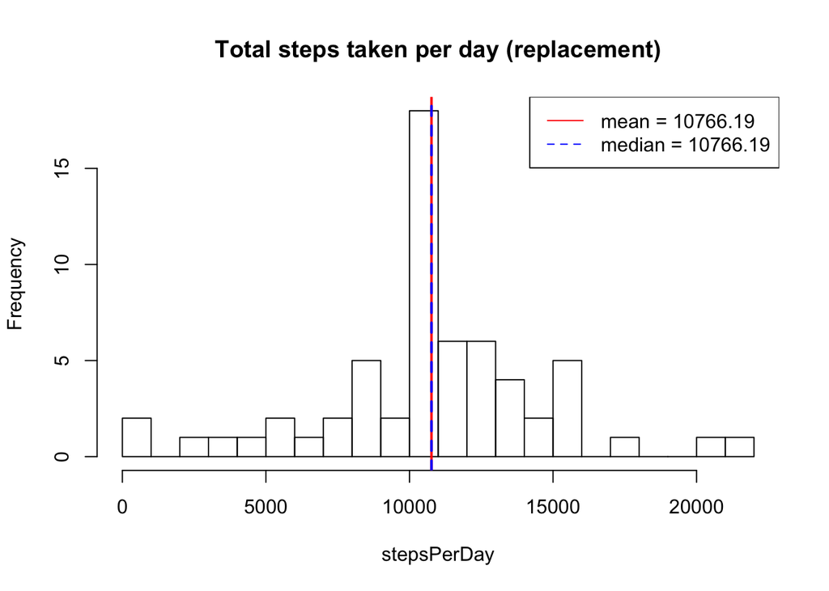

```r
text_legend1 <- paste("mean",round(mean_stepsPerDay,digits=2),sep = " = ")
text_legend2 <- paste("median",round(median_stepsPerDay,digits=2),sep = " = ")
with(dataMutated,{ hist(stepsPerDay,
                        main = "Total steps taken per day (replacement)",
                        breaks = 30)
        abline(v = mean_stepsPerDay,col = "red",lwd = 2)
        abline(v = median_stepsPerDay,col = "blue",lwd = 2,lty=2)
        legend("topright",lty=c(1,2),col=c("red","blue"),
               legend=c(text_legend1,text_legend2) ) })
```

### Total number of steps taken per day (replacement VS ignoring NA’s)

The strategy followed to replace the missing values, is to place them with the corresponding mean of their interval, as computed from the available data. In the previous example the missing values were ignored, and a large number of days ended up with sum of steps equal to zero. In this case the missing values were replaced by the mean of their corresponding interval,the number of days with zero steps per day are less than before. As a result the mean and median are now the same, and the distribution is similar to a Normal distibution.

## Are there differences in activity patterns between weekdays and weekends?